# Qué y cómo aprenden las máquinas

Sebastian Castillo

6 de diciembre de 2018

# Introduccion

Para este análisis voy a emplear un ejemplo clásico de implementación de un algoritmo de clasificación explicado en *Deep Learning with R*, Chollet-Allaire, 2017. Este algoritmo construye una *red neuronal* para clasificar imágenes de números enteros de un dígito en su correspondiente categoría 0 a 9. El data set de *entrenamiento* de la red es de 60000 imágenes y el de prueba (para determinar la exactitud de las predicciones) es de 10000. Esta base de datos fue recopilada por el Instituto Nacional de Estándares y Tecnología de Estados Unidos, y forma parte del paquete Keras disponible en R.

# Habilitando el data set de entrenamiento y de testeo

```r
library(keras)
library(dplyr)

mnist <- dataset_mnist()
train_images <- mnist$train$x
train_labels <- mnist$train$y
test_images <- mnist$test$x
test_labels <- mnist$test$y
```

Algo de exploración de los objetos:

```r
# Explorando el array
str(train_images)
```

```
##  int [1:60000, 1:28, 1:28] 0 0 0 0 0 0 0 0 0 0 ...
```

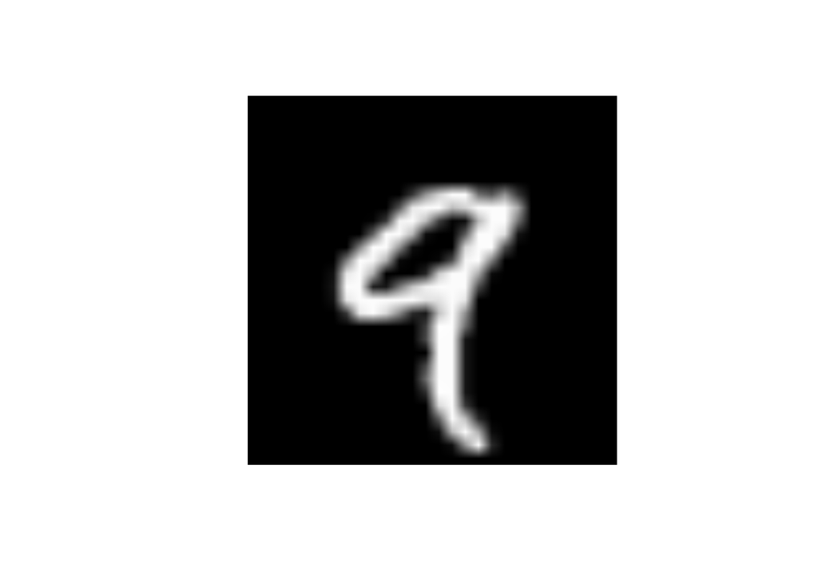

```r
# Explorando un elemento
digit <- train_images[5,,]

plot(as.raster(digit, max = 255))
```

```r
str(train_labels)
```

```
##  int [1:60000(1d)] 5 0 4 1 9 2 1 3 1 4 ...
```

```r
str(test_images)
```

```
##  int [1:10000, 1:28, 1:28] 0 0 0 0 0 0 0 0 0 0 ...
```

```r
str(test_labels)
```

```
##  int [1:10000(1d)] 7 2 1 0 4 1 4 9 5 9 ...
```

# Construyendo la Red Neuronal

Esta implementación en dos capas (*layers*) densamente conectadas, con una capa final que organiza las salidas de la red en 10 categorías.

```r
# network of two layers densely connected

network <- keras_model_sequential() %>%
  layer_dense(units = 512, activation = "relu", input_shape = c(28 * 28)) %>% #
  layer_dense(units = 10, activation = "softmax")
```

Chollet-Allaire explican que las redes neuronales tienen como elemento fundamental para el procesamiento de datos a las “capas” o “estratos” que filtran los datos de entrada de tal manera de generar salidas útiles para responder a un problema particular. En el caso bajo estudio las capas generan *representaciones* de los datos que resultan útiles para la tarea de clasificación. En líneas generales la mayoría de las técnicas de *deep learning* (aprendizaje profundo) consisten en el encadenamiento de múltiples capas, cada una simple en su tarea de procesamiento o producción de representación, que progresivamente transforman la entrada en un tipo particular de salida.

Otros componentes elementales de una Red Neuronal son:

- *función de pérdida (loss function)* que mide la calidad de la predicción permitiendo a la red ajustar sus parámetros para mejorar su desempeño. Esta función *cuantifica que tan triste vas a estar* -dice Liang- *si utilizas la función W para predecir x cuando la respuesta correcta es y.* Por eso debemos buscar minimizar su resultado (link a las diapositivas de Liang en el curso de IA de Stanford [aquí](https://web.stanford.edu/class/cs221/lectures/learning1.pdf)).
- *un optimizador* mecanismo que permite a la red actualizarse considerando el dato que tiene para clasificar y el resultado obtenido de la función de pérdida.
- *medida de desempeño de la red* en este caso es la exactitud (accuracy) de la predicción.

Estos elementos se especifican para la implementación en R de esta forma:

```r
network %>% compile(
  optimizer = "rmsprop",
  loss = "categorical_crossentropy",
  metrics = c("accuracy")
)
```

Antes de empezar, necesitamos adecuar los datos al formato esperado por la red.

```r
train_images <- array_reshape(train_images, c(60000, 28 * 28))
train_images <- train_images / 255

test_images <- array_reshape(test_images, c(10000, 28 * 28))
test_images <- test_images / 255
```

Debemos formatear las etiquetas del data set como variables categóricas.

```r
train_labels <- to_categorical(train_labels)
test_labels <- to_categorical(test_labels)
```

Ahora sí, entrenando la red:

```r
network %>% fit(train_images, train_labels, epochs = 5, batch_size = 128)
```

[output not shown]

A partir del *aprendizaje* logrado por la red, ahora la aplicamos a los datos de prueba:

```r
metrics <- network %>% evaluate(test_images, test_labels, verbose = 0)
metrics
```

```
## $loss
## [1] 0.06639481
##
## $acc
## [1] 0.9789
```

# Generando predicciones sobre nuevas imágenes

```r
 network %>% predict_classes(test_images[1:10,])
```

```
##  [1] 7 2 1 0 4 1 4 9 5 9
```